# yangy22-data-replication-assignment

Emily Yang

2023-12-12

# A rodent herbivore reduces its predation risk through ecosystem engineering

## Background

The environment plays a role in predator-prey relationships. This paper studied Brandt’s voles which modify their habitat by cutting down bunchgrass (Achnatherum splendens) in the presence of shrikes. A. splendens grass is unpalatable and not a vole food source. Shrikes perch on these bunchgrasses to hunt voles and also impale voles grass spikes for later consumption. By decreasing the volume of bunchgrass voles reduced visitations by shrikes leading to a drop in vole mortality rates. Their ecosystem engineering through damaging roots and clipping leaves can directly reduce their own predation risk by modifying habitat structure.

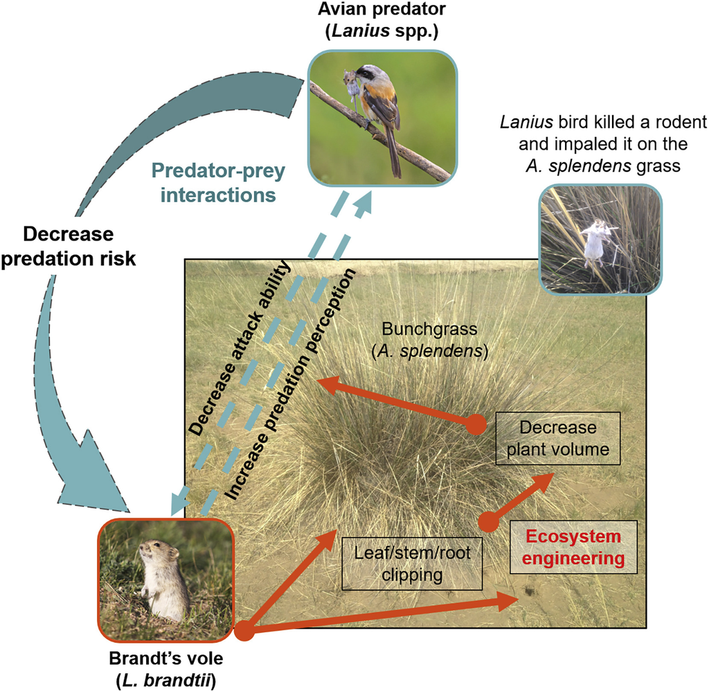

## Data Description

The data set I used was deposited on Dryad. https://datadryad.org/stash/dataset/doi:10.5061/dryad.cvdncjt57  
Column A-E: Data used to generate Figure 2A  
Column G-K: Data used to generate Figure 2B  
Column M-Q: Data used to generate Figure 3  
Column R-X: Data used to generate Figure 4

```r
library(dplyr)
library(tidyverse)
```

```r
library(ggplot2)
library(ggpubr)

d <- read.csv("Ecosystem_engineers_and_predation_risk_data_-.csv")
head(d)
```

```
##   Pair_number Vole_Presence Initial_plantvol Final_plantvol Change_plantvol
## 1           1       No vole             4.17           4.81            0.63
## 2           2       No vole             7.18           6.10           -1.08
## 3           3       No vole             8.78          10.32            1.53
## 4           4       No vole             0.61           1.23            0.62
## 5           5       No vole             1.30           1.46            0.16
## 6           6       No vole            13.02          11.55           -1.47
##   plot Plant_cover Birds_June Birds_July Birds_August Birds_total15 Block
## 1    1           9          0          1            0             1     1
## 2    2          28          2          0            0             2     2
## 3    3          12          0          0            0             0     3
## 4    4          23          0          0            0             0     4
## 5    5          34          0          2            1             3     5
## 6    6          20          0          0            0             0     6
##      Predator  Rodent Bird_visits Change_plantvol2 Change_biomass Plant_cover2
## 1 No predator No vole           0             1.54            -44            0
## 2 No predator No vole           1             2.11            119            0
## 3 No predator No vole           0             1.93            -30            0
## 4 No predator No vole           0             2.03             52            0
## 5 No predator No vole           0             1.48             88            0
## 6 No predator No vole           2             2.17            -61            0
##   block Feeding_freq Bird_visit6 Voles_initial Voles_recaptured Vole_mortality
## 1     1           60           0             4                2             50
## 2     2           80           1             4                4              0
## 3     3           50           3             4                4              0
## 4     4           80           1             4                3             25
## 5     5           90           1             4                2             50
## 6     6           70           2             4                4              0
```

```r
options(warn=-1) # to get rid of all the package warnings
```

## Figure 2

Inferential Statistic + Figure Replication

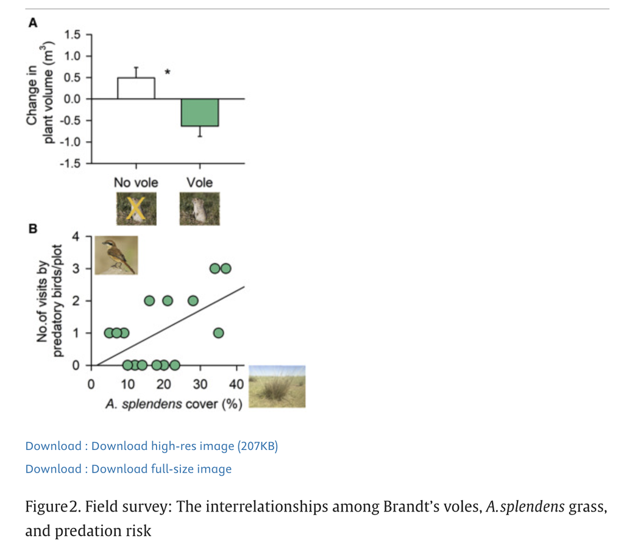

Figure 2 was about observing randomly 15 pairs of randomly selected A. splendens grass bunches 15 with voles and 15 without. The paired grass bunches were at least 15 meters apart and 30 meters away from other pairs. They recorded the presence of voles and presence of birds and found that vole presence had an effect on A. splendens size and the amount of grass coverage affected how often predatory shrikes would visit.

### Figure 2A

```r
n <- d %>%
 group_by(Vole_Presence) %>% # Compared by vole presence
  summarise_each(funs(mean,sd,se=sd(.)/sqrt(n())), Change_plantvol) # Find mean SD and SE of changes in plant volume.
n
```

```
## # A tibble: 2 × 4
##   Vole_Presence   mean    sd    se
##   <chr>          <dbl> <dbl> <dbl>
## 1 No vole        0.494 0.935 0.241
## 2 Vole          -0.631 0.927 0.239
```

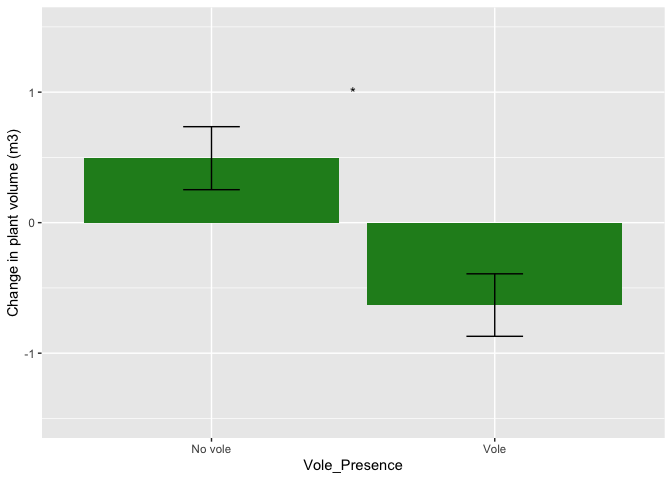

```r
m <- as.data.frame(n)

g <- ggplot(m) +
  geom_col(aes(y=mean, x=Vole_Presence), fill="forestgreen") + #add columns
  geom_errorbar( aes(x=Vole_Presence,ymin=mean-se, ymax=mean+se), width=0.2, colour="black") + #add error bars. Can't make single sided error bars
ylab("Change in plant volume (m3)") + ylim(-1.5, 1.5) + # adjusting y axis
  annotate('text', x = 1.5, y = 1, label='"*"', parse=TRUE) # add significance from the anova below. Only one star used because the paper only marked signif and not degree.

g
```

I summarized change in plant volume according to vole presence and made a barplot. The error bars are mean +/- the standard error. Using the inferential anova below I decided that the difference in the means was significantly different.

They found that the average plant volume of A. splendens grass, given vole presence, was reduced by 0.63 m3, whereas the average plant volume of A. splendens in the absence of voles increased by 0.49 m3, as compared to the initial conditions (F1, 14 = 15.09; p = 0.0017; Figure 2A). I tested the data using a repeated measures anova.

```r
# Repeated measures anova change in plant volume predicted by vole presence.
model <- aov(Change_plantvol~factor(Vole_Presence)+Error(factor(Pair_number)), data = d)
summary(model)
```

```
##
## Error: factor(Pair_number)
##           Df Sum Sq Mean Sq F value Pr(>F)
## Residuals 14  15.46   1.104
##
## Error: Within
##                       Df Sum Sq Mean Sq F value  Pr(>F)
## factor(Vole_Presence)  1  9.498   9.498   15.09 0.00165 **
## Residuals             14  8.813   0.629
## ---
## Signif. codes:  0 '***' 0.001 '**' 0.01 '*' 0.05 '.' 0.1 ' ' 1
```

I chose a repeated measures anova because I wanted to see if there was a significant difference in the change in plant volume of each paired group. I found the same F and p values with a significance of 0.01. The authors didn’t say what type of test was used to get their statistical results. I had tried a one way anova and gotten values that were close but double the degrees of freedom.

### Figure 2B

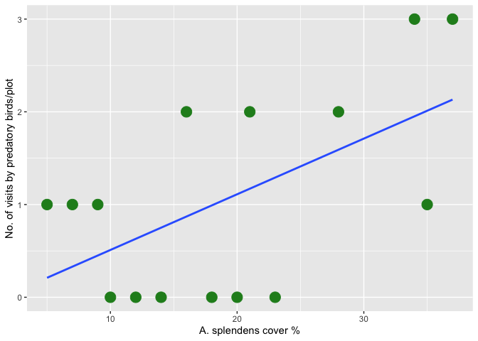

```r
ggplot(d, aes(x=as.numeric(Plant_cover), y=as.numeric(Birds_total15))) +
  geom_point(colour = "forestgreen", size = 5) +
  geom_smooth(method = "lm", se=FALSE) + # Add trendline
  xlab("A. splendens cover %") + ylab("No. of visits by predatory birds/plot")
```

Figure 2B was about plotting the relationship between plant coverage and visits by predatory birds. There is a positive correlation between the two variables which makes sense since more plant coverage = more hunting perches for the birds.

The paper reports: The total number of visits by predatory birds per plot was positively correlated with the coverage of A. splendens grass (pseudo-R2 = 0.252; z-ratio = 2.185; p = 0.029; Figure 2B).

```r
# Generalized Linear Model
glm <- glm(data = d, Birds_total15 ~ Plant_cover, family= "poisson")
summary(glm)
```

```
##
## Call:
## glm(formula = Birds_total15 ~ Plant_cover, family = "poisson",
##     data = d)
##
## Coefficients:
##             Estimate Std. Error z value Pr(>|z|)
## (Intercept) -1.12229    0.66214  -1.695   0.0901 .
## Plant_cover  0.05373    0.02459   2.185   0.0289 *
## ---
## Signif. codes:  0 '***' 0.001 '**' 0.01 '*' 0.05 '.' 0.1 ' ' 1
##
## (Dispersion parameter for poisson family taken to be 1)
##
##     Null deviance: 19.436  on 14  degrees of freedom
## Residual deviance: 14.539  on 13  degrees of freedom
##   (15 observations deleted due to missingness)
## AIC: 40.364
##
## Number of Fisher Scoring iterations: 5
```

```r
#calculate McFadden's R-squared for model
with(summary(glm), 1 - deviance/null.deviance)
```

```
## [1] 0.2519348
```

I chose to do a generalized linear model because the number of visits is a discrete variable. I got a z value of 2.185 and a p value 0.0289 which match with reported data. I then calculated McFadden’s R-squared which turned out to be 0.2519348 matching the reported psudo-R2

## Figure 3

Summary Statistics

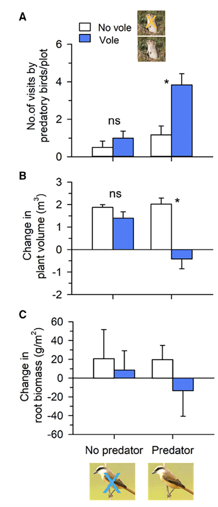

Figure 3 was a Semi-natural manipulative experiment to study how the predation risk affected vole activity. They fenced off 12 plots so shrikes could not attack the voles and had 12 plots open to the air. In half of each set they placed a pair of subadult voles. In total there were 6 replicates of each condition. The only two significant findings were that birds more frequently visited plots with voles if not fenced off and that voles significantly decreased plant volume in the presence of birds.

I worked really hard on this and didn’t want to delete the whole thing even though the graphs are not what I wanted. The tables accurately report the mean, SD, SE of each variable that I made throught the tidyverse. The graphs are supposed to be barcharts reporting the mean and error bars for the standard error of the mean. I was unable to make bars sorted by both predator presence and rodent presence. In the end I was able to make a boxplot which show the median and quantiles of the data which are sorted by both predator presence and rodent presence. This shows some similar trends but the graphs are not the same as the paper.

### Figure 3A

```r
# First make a dataframe with just the variable we are interested in

t <-
  d %>%
  select("Predator","Rodent","Bird_visits","Change_plantvol2", "Change_biomass") %>%
  filter(Predator != "")
head(t)
```

```
##      Predator  Rodent Bird_visits Change_plantvol2 Change_biomass
## 1 No predator No vole           0             1.54            -44
## 2 No predator No vole           1             2.11            119
## 3 No predator No vole           0             1.93            -30
## 4 No predator No vole           0             2.03             52
## 5 No predator No vole           0             1.48             88
## 6 No predator No vole           2             2.17            -61
```

```r
# Sort by both predator and rodent
q <- t %>% group_by(Predator, Rodent) %>%
summarise_each(funs(mean,sd,se=sd(.)/sqrt(n())), Bird_visits) # Find mean, SD, SE
q# Data of the Mean and SD since the boxplot isn't ideal
```

```
## # A tibble: 4 × 5
## # Groups:   Predator [2]
##   Predator    Rodent   mean    sd    se
##   <chr>       <chr>   <dbl> <dbl> <dbl>
## 1 No predator No vole  0.5  0.837 0.342
## 2 No predator Vole     1    0.894 0.365
## 3 Predator    No vole  1.17 1.17  0.477
## 4 Predator    Vole     3.83 1.47  0.601
```

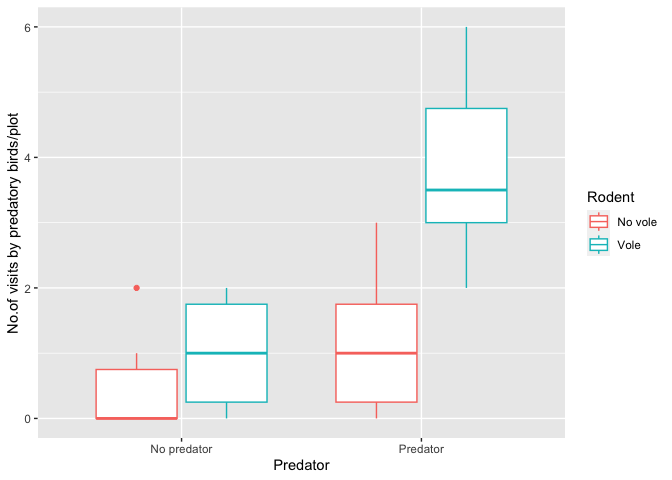

```r
# Make a Boxplot since Barplot won't work
g <- ggplot(data = t, aes(y=Bird_visits, x=Predator, color=Rodent)) +
  geom_boxplot() + ylab("No.of visits by predatory birds/plot") + ylim(0, 6)
g
```

My graph shows the medians of visits by predatory birds per treatment condition. There was a significant difference between vole and no vole when predators were present.

### Figure 3B

```r
# Sort by both predator and rodent
r <- t %>% group_by(Predator, Rodent) %>%
summarise_each(funs(mean,sd,se=sd(.)/sqrt(n())), Change_plantvol2) # Find mean, SD, SE
r
```

```
## # A tibble: 4 × 5
## # Groups:   Predator [2]
##   Predator    Rodent    mean    sd    se
##   <chr>       <chr>    <dbl> <dbl> <dbl>
## 1 No predator No vole  1.88  0.296 0.121
## 2 No predator Vole     1.40  0.697 0.285
## 3 Predator    No vole  2.02  0.649 0.265
## 4 Predator    Vole    -0.417 1.06  0.434
```

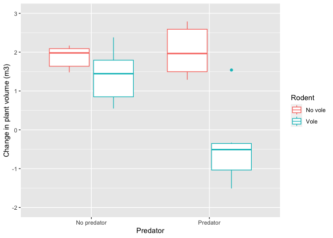

```r
g <- ggplot(data = t, aes(y=Change_plantvol2, x=Predator, color=Rodent)) +
  geom_boxplot() + ylab("Change in plant volume (m3)") + ylim(-2, 3)
g
```

My graph shows the medians of change in above ground plant volume per treatment condition. There was a significant difference between vole and no vole when predators were present.

### Figure 3C

```r
# Sort by both predator and rodent
s <- t %>% group_by(Predator, Rodent) %>%
summarise_each(funs(mean,sd,se=sd(.)/sqrt(n())), Change_biomass) # Find mean, SD, SE
s
```

```
## # A tibble: 4 × 5
## # Groups:   Predator [2]
##   Predator    Rodent   mean    sd    se
##   <chr>       <chr>   <dbl> <dbl> <dbl>
## 1 No predator No vole  20.7  75.6  30.9
## 2 No predator Vole      8.5  50.4  20.6
## 3 Predator    No vole  19.7  37.2  15.2
## 4 Predator    Vole    -13.3  67.2  27.4
```

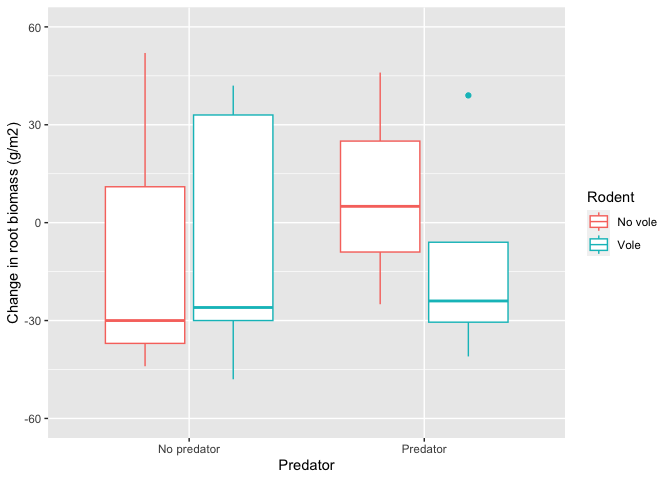

```r
g <- ggplot(data = t, aes(y=Change_biomass, x=Predator, color=Rodent)) +
  geom_boxplot() + ylab("Change in root biomass (g/m2)") + ylim(-60, 60)

g
```

My graph shows the medians of change in below ground root biomass per treatment condition. There were no significant findings.

## Figure 4

Descriptive Statistic

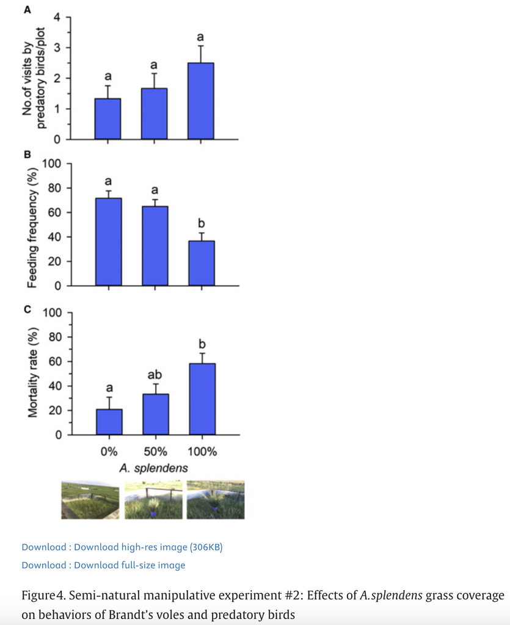

Figure 4 was a semi-natural manipulative experiment to study the effects of grass coverage on bird and vole behavior. Four voles were placed in each plot and recaptured at then end of the experiment to calculate mortality. The A. splendens grass was transplanted into buckets so the voles are unable to damage them. The differing amounts of grass coverage didn’t affect total bird visits per plot 4A but did significantly affect vole feeding behavior 4B and vole mortality 4C.

### Figure 4A

```r
# Select the data we want to use for Figure 4
o <- d[1:18, c(18, 20, 21, 24)]
o <- data.frame(sapply(o, function(x) as.numeric(as.character(x))))
head(o)
```

```
##   Plant_cover2 Feeding_freq Bird_visit6 Vole_mortality
## 1            0           60           0             50
## 2            0           80           1              0
## 3            0           50           3              0
## 4            0           80           1             25
## 5            0           90           1             50
## 6            0           70           2              0
```

```r
# Find mean, SD, SE for all three
a <- o %>% group_by(Plant_cover2) %>%
  summarise_each(funs(mean,sd,se=sd(.)/sqrt(n())), 1:3)
head (a)
```

```
## # A tibble: 3 × 10
##   Plant_cover2 Feeding_freq_mean Bird_visit6_mean Vole_mortality_mean
##          <dbl>             <dbl>            <dbl>               <dbl>
## 1            0              71.7             1.33                20.8
## 2           50              65               1.67                33.3
## 3          100              36.7             2.5                 58.3
## # ℹ 6 more variables: Feeding_freq_sd <dbl>, Bird_visit6_sd <dbl>,
## #   Vole_mortality_sd <dbl>, Feeding_freq_se <dbl>, Bird_visit6_se <dbl>,
## #   Vole_mortality_se <dbl>
```

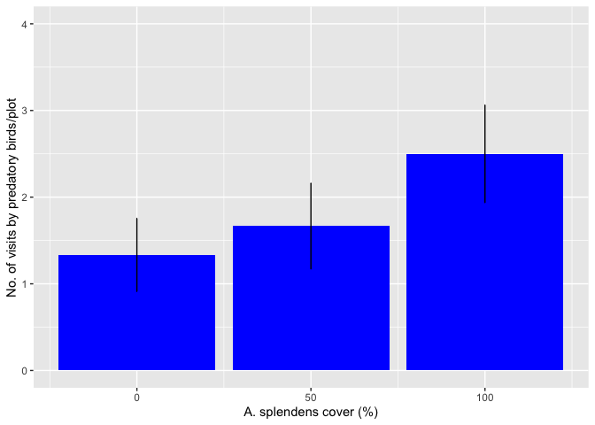

```r
g1 <- ggplot(a, aes(x=Plant_cover2, y=Bird_visit6_mean)) +
  geom_col(fill="blue") +
  geom_errorbar( aes(x=Plant_cover2,ymin=Bird_visit6_mean-Bird_visit6_se, ymax=Bird_visit6_mean+Bird_visit6_se), width=0.2, colour="black") +
  xlab("A. splendens cover (%)") + ylab("No. of visits by predatory birds/plot") +
scale_x_continuous(breaks=c(0,50,100)) + ylim(0,4)
g1
```

There is a positive trend of more total bird visits with increasing grass coverage but it was not found to be significant.

### Figure 4B

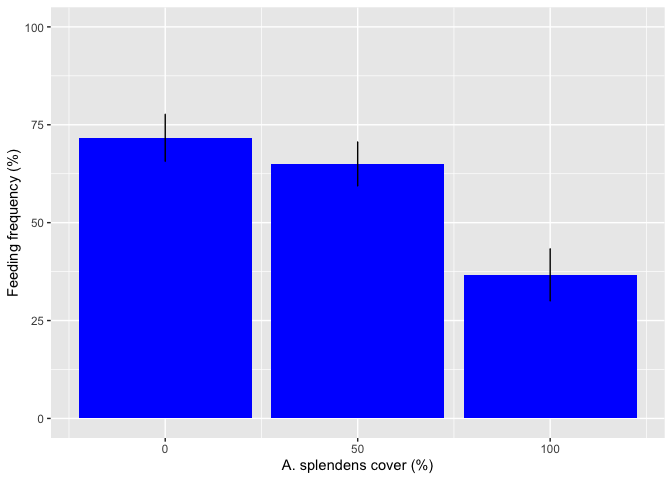

```r
g2 <- ggplot(a, aes(x=Plant_cover2, y=Feeding_freq_mean)) +
  geom_col(fill="blue") +
  geom_errorbar( aes(x=Plant_cover2,ymin=Feeding_freq_mean-Feeding_freq_se, ymax=Feeding_freq_mean+Feeding_freq_se), width=0.2, colour="black") +
  xlab("A. splendens cover (%)") + ylab("Feeding frequency (%)") +
  scale_x_continuous(breaks=c(0,50,100)) + scale_y_continuous(breaks=c(0, 20, 40, 60, 80, 100)) + ylim(0,100)
g2
```

We can see a significant difference in vole feeding frequency between the 100% plant coverage and the other two conditions.

### Figure 4C

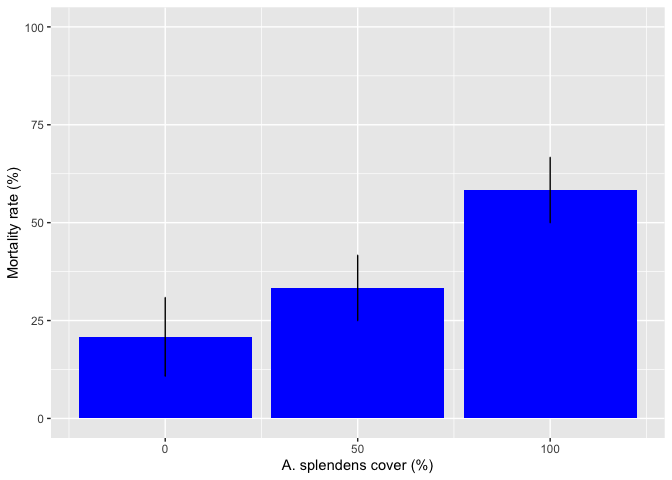

```r
g3 <- ggplot(a, aes(x=Plant_cover2, y=Vole_mortality_mean)) +
  geom_col(fill="blue") +
  geom_errorbar( aes(x=Plant_cover2,ymin=Vole_mortality_mean-Vole_mortality_se, ymax=Vole_mortality_mean+Vole_mortality_se), width=0.2, colour="black") +
xlab("A. splendens cover (%)") + ylab("Mortality rate (%)") +
  scale_x_continuous(breaks=c(0,50,100)) + ylim(0,100)
g3
```

## Conclusions

This was a very interesting paper to read because we usually hear more about animals adapting to their environments and less about animals adapting their environment to avoid predators. It was a bit hard to figure out what statistical tests I need to run for the figures but it ended up fine. I learned a lot about sorting and sectioning data as well as different graphing functions.